# 3 Виконання

## 3.1 Побудувати графік зміни середніх денних температур: 1. загальний; 2. за 2014 рік; 3. за квітень 2013 року; 4. за листопад 2013 –травень 2015; 5. за 2015 та 2016 на одному графіку

### Для початку імпортуємо модуль numpy, pandas, seaborn та matplotlib, завантажимо дані до датафрейму, використавши колонку date як індекс.

```python
import numpy as np
import pandas as pd
import seaborn as sns
import matplotlib.pyplot as plt
df = pd.read_csv('data/Delhi_Climate.csv',
                 index_col=['date'], parse_dates=['date'])
df
```

| date | meantemp | humidity | wind_speed | meanpressure |
| --- | --- | --- | --- | --- |
| 2013-01-01 | 10.000000 | 84.500000 | 0.0 | 1015.666667 |
| 2013-01-02 | 7.400000 | 92.000000 | 2.98 | 1017.800000 |
| 2013-01-03 | 7.166667 | 87.000000 | 4.633333333333334 | 1018.666667 |
| 2013-01-04 | 8.666667 | 71.333333 | 1.2333333333333334 | 1017.166667 |
| 2013-01-05 | 6.000000 | 86.833333 | 3.6999999999999997 | 1016.500000 |
| ... | ... | ... | ... | ... |
| 2016-12-28 | 17.217391 | 68.043478 | 3.547826086956522 | 1015.565217 |
| 2016-12-29 | 15.238095 | 87.857143 | 6.0 | 1016.904762 |
| 2016-12-30 | 14.095238 | 89.666667 | 6.266666666666667 | 1017.904762 |
| 2016-12-31 | 15.052632 | 87.000000 | 7.325 | 1016.100000 |
| 2017-01-01 | 10.000000 | 100.000000 | 0.0 | 1016.000000 |

1462 rows × 4 columns

*Завантаження даних*

### Побудуємо графік денних температур застосувавши метод pandas.Series.plot.

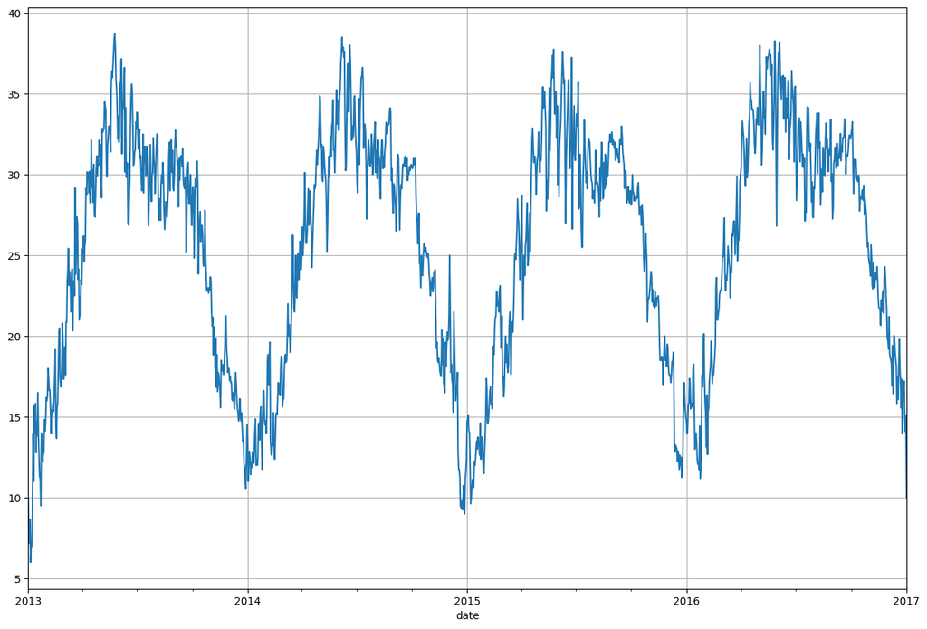

```python
fig, ax = plt.subplots(figsize=(15, 10))
df.meantemp.plot(ax=ax)
ax.grid()
```

*Графік денних температур*

### Побудуємо графік температур за 2014 рік.

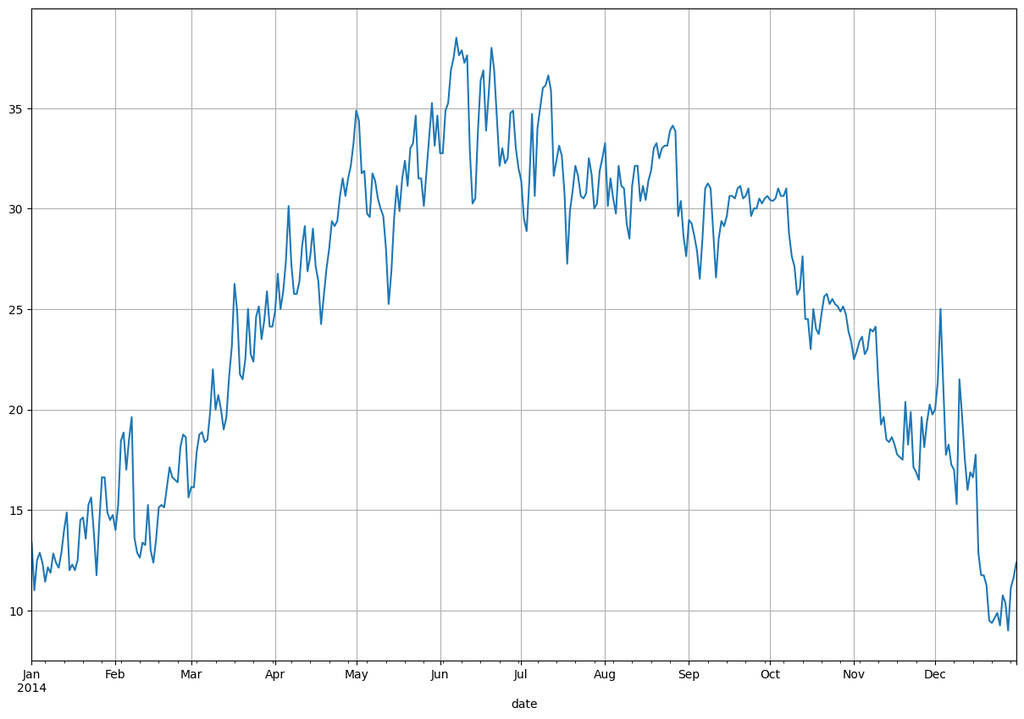

```python
fig, ax = plt.subplots(figsize=(15, 10))
df['2014'].meantemp.plot(ax=ax)
ax.grid()
```

*Графік зміни середніх денних температур за 2014 рік*

```python
april = df['2013-04']
april
```

| date | meantemp | humidity | wind_speed | meanpressure |
| --- | --- | --- | --- | --- |
| 2013-04-01 | 25.375000 | 45.500000 | 4.4 | 1008.500000 |
| 2013-04-02 | 25.166667 | 51.000000 | 8.65 | 1009.500000 |
| 2013-04-03 | 26.200000 | 45.600000 | 8.14 | 1009.000000 |
| 2013-04-04 | 24.600000 | 41.800000 | 11.120000000000001 | 1007.800000 |
| 2013-04-05 | 25.600000 | 31.000000 | 15.559999999999999 | 1007.000000 |
| 2013-04-06 | 25.857143 | 29.857143 | 11.900000000000002 | 1006.142857 |
| 2013-04-07 | 29.142857 | 23.285714 | 10.314285714285715 | 1005.000000 |
| 2013-04-08 | 28.714286 | 33.857143 | 5.3 | 1006.000000 |
| 2013-04-09 | 30.166667 | 30.500000 | 8.65 | 1005.333333 |
| 2013-04-10 | 30.000000 | 28.000000 | 6.1 | 1006.714286 |
| 2013-04-11 | 30.000000 | 24.200000 | 7.780000000000001 | 1006.400000 |
| 2013-04-12 | 28.857143 | 32.571429 | 6.342857142857143 | 1007.571429 |
| 2013-04-13 | 30.200000 | 29.200000 | 10.000000000000002 | 1008.400000 |
| 2013-04-14 | 28.250000 | 39.375000 | 6.487499999999999 | 1007.000000 |
| 2013-04-15 | 28.250000 | 41.375000 | 6.25 | 1003.875000 |
| 2013-04-16 | 32.125000 | 24.625000 | 10.424999999999999 | 1000.000000 |
| 2013-04-17 | 29.200000 | 24.200000 | 6.659999999999999 | 1002.200000 |
| 2013-04-18 | 30.285714 | 30.285714 | 4.757142857142858 | 1002.857143 |
| 2013-04-19 | 28.285714 | 31.285714 | 3.971428571428571 | 1002.571429 |
| 2013-04-20 | 30.625000 | 29.000000 | 7.6375 | 1003.375000 |
| 2013-04-21 | 27.666667 | 38.666667 | 13.883333333333333 | 1006.833333 |
| 2013-04-22 | 27.375000 | 45.375000 | 7.650000000000001 | 1010.000000 |
| 2013-04-23 | 28.625000 | 44.125000 | 4.625000000000001 | 1009.875000 |
| 2013-04-24 | 30.285714 | 41.714286 | 2.1142857142857143 | 1008.571429 |
| 2013-04-25 | 31.142857 | 38.285714 | 3.7 | 1007.714286 |
| 2013-04-26 | 29.875000 | 45.875000 | 6.7125 | 1008.375000 |
| 2013-04-27 | 31.142857 | 31.428571 | 13.485714285714286 | 1007.000000 |
| 2013-04-28 | 30.571429 | 28.000000 | 12.971428571428572 | 1005.428571 |
| 2013-04-29 | 32.125000 | 26.375000 | 7.875 | 1004.875000 |
| 2013-04-30 | 31.142857 | 32.000000 | 7.928571428571429 | 1004.857143 |

### Побудуємо графік середніх температур за квітень 2013 року.

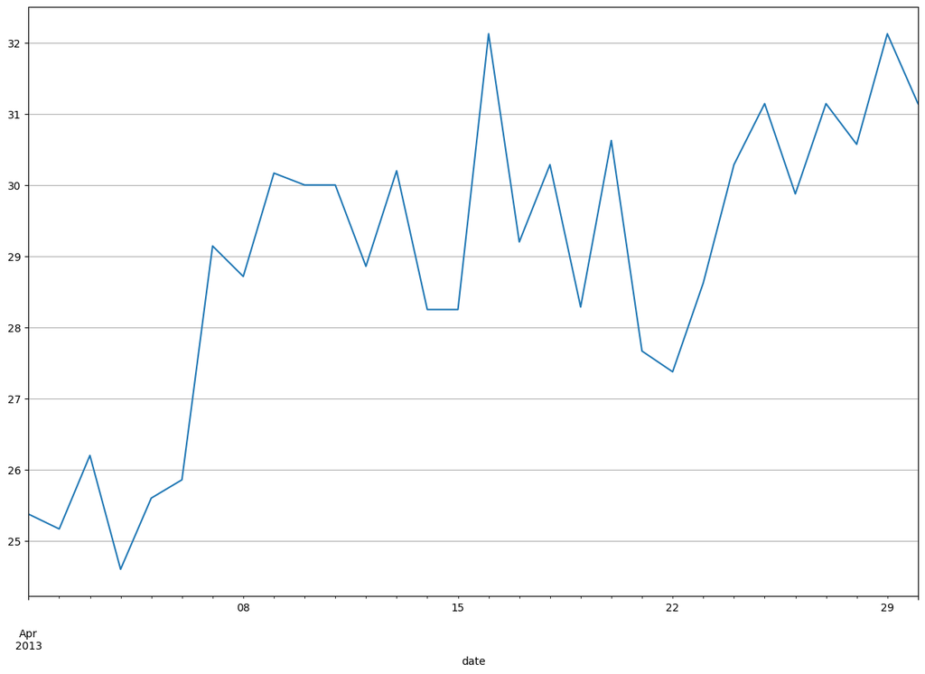

```python
fig, ax = plt.subplots(figsize=(15, 10))
april.meantemp.plot(ax=ax)
ax.grid()
```

*Графік середніх температур за квітень 2013 року*

### Виконаємо знаходження даних за допомогою атрибута loc для побудови графіку середніх денних температур з листопада 2013-го по травень 2015-го.

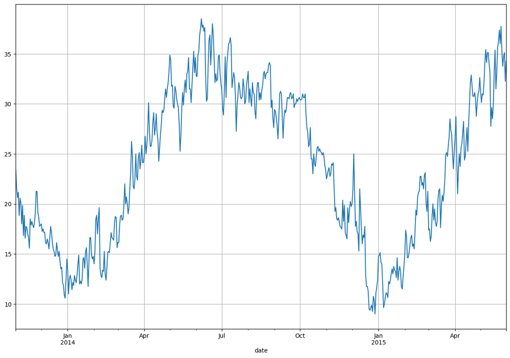

```python
nov_may = df.loc['2013-11':'2015-05']
fig, ax = plt.subplots(figsize=(15, 10))
nov_may.meantemp.plot(ax=ax)
ax.grid()
```

*Графік середніх денних температур з листопада 2013-го по травень 2015-го*

### Побудуємо на одному графіку дані середніх денних температур за 2015 та 2016 рік.

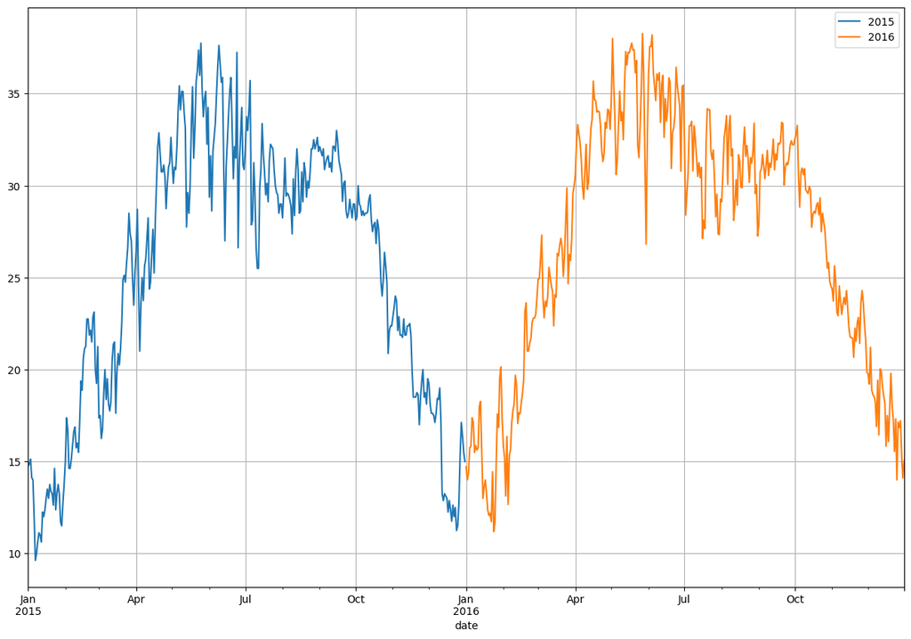

```python
years = ['2015', '2016']
fig, ax = plt.subplots(figsize=(15, 10))
for y in years:
    df[y].meantemp.plot(ax=ax)
ax.grid()
plt.legend(years)
```

*Графік середніх денних температур за 2015-ий та 2016-ий роки*

## 3.2 Знайти середні значення вологості 1. за 2016 рік; 2. за кожний місяць; 3. за кожні два тижні весни та літа 2014 року. 4. Розрахувати і зобразити зміни вологості у відсотках за кожен день впродовж літа 2015 року. 5. Знайти та зобразити графічно ковзне середнє вологості за 2013 рік з вікном в місяць.

### Знайдемо середні значення вологості за 2016-ий рік.

```python
df[df.index.year == 2016].humidity.mean()
```

```
58.74017392187424
```

*Середнє значення вологості за 2016-ий рік*

### Знайдемо середнє значення вологості за кожен місяць кожного року. Використаємо метод resample для агрегування значень у періоди.

```python
df.resample('1M').humidity.mean()
```

```
date
2013-01-31     73.028802
2013-02-28     71.938563
2013-03-31     57.417243
2013-04-30     34.612103
2013-05-31     28.938249
2013-06-30     58.758135
2013-07-31     74.873387
2013-08-31     76.757104
2013-09-30     64.552738
2013-10-31     70.255607
2013-11-30     66.245952
2013-12-31     79.134409
2014-01-31     84.572581
2014-02-28     73.336097
2014-03-31     62.323733
2014-04-30     40.657738
2014-05-31     41.742512
2014-06-30     42.675000
2014-07-31     62.846368
2014-08-31     61.418262
2014-09-30     63.385714
2014-10-31     59.094662
2014-11-30     55.333333
2014-12-31     69.948157
2015-01-31     78.189516
2015-02-28     64.376913
2015-03-31     68.015553
2015-04-30     51.632143
2015-05-31     33.320276
2015-06-30     49.322024
2015-07-31     69.376152
2015-08-31     70.710685
2015-09-30     53.948690
2015-10-31     59.313748
2015-11-30     66.825000
2015-12-31     71.646313
2016-01-31     77.932892
2016-02-29     62.385095
2016-03-31     55.037324
2016-04-30     29.244164
2016-05-31     38.958726
2016-06-30     51.759739
2016-07-31     75.429839
2016-08-31     72.993345
2016-09-30     61.011111
2016-10-31     56.218619
2016-11-30     54.051350
2016-12-31     68.840384
2017-01-31    100.000000
Freq: M, Name: humidity, dtype: float64
```

*Дані про середню вологість за кожний місяць з включно 2013 по 2018 виключно*

### Знайдемо середні значення вологості за кожні два тижні весни та літа 2014 року.

```python
df['2014-03':'2014-08'].resample('2W').mean()
```

| date | meantemp | humidity | meanpressure |
| --- | --- | --- | --- |
| 2014-03-02 | 16.133929 | 83.142857 | 1016.205357 |
| 2014-03-16 | 19.881378 | 63.723214 | 1015.801020 |
| 2014-03-30 | 23.904337 | 59.250000 | 1010.687500 |
| 2014-04-13 | 26.669643 | 41.543367 | 1008.798469 |
| 2014-04-27 | 28.258929 | 42.857143 | 1008.910714 |
| 2014-05-11 | 31.594388 | 36.492347 | 1003.422194 |
| 2014-05-25 | 30.678571 | 42.383929 | 1004.741071 |
| 2014-06-08 | 34.625000 | 36.991071 | 999.603316 |
| 2014-06-22 | 35.178571 | 42.982143 | 995.107143 |
| 2014-07-06 | 32.212127 | 59.030987 | 999.063884 |
| 2014-07-20 | 33.008929 | 58.241071 | 996.562500 |
| 2014-08-03 | 31.381378 | 67.325255 | 998.734694 |
| 2014-08-17 | 30.779562 | 66.380233 | 999.182379 |
| 2014-08-31 | 31.998724 | 55.081633 | 1002.774235 |

*Середні значення вологості за кожні два тижні весни та літа 2014 року*

### Розрахуємо і зобразимо зміни вологості у відсотках за кожен день впродовж літа 2015 року. Використаємо метод pct_change для знаходження зміни у відсотках.

```python
dd = df['2015-06':'2015-08'].humidity.pct_change()
```

*Знаходження зміни вологості у відсотках*

### Зобразимо вище знайдені дані.

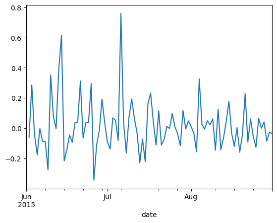

```python
dd.plot()
```

*Uhfasr зміни вологості у відсотках*

### Знайдемо та зобразимо графічно ковзне середнє вологості за 2013 рік з вікном в місяць.

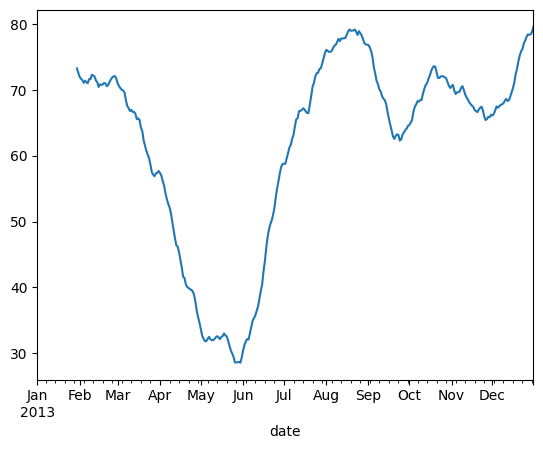

```python
df['2013'].rolling(30).humidity.mean().plot()
```

*Графік ковзного середнього вологості за 2013 рік з вікном в місяць*